# Data Science Capstone - Exploratory Analysis

Aleksandra Cvetanovska

11/21/2021

## Exploratory Analysis

### Basic Summary

```r
max(unlist(char_num_twitter)) # Number of characters of the longest tweet
```

```
## [1] 140
```

```r
max(unlist(char_num_blogs)) # Number of characters of the longest blog post
```

```
## [1] 40833
```

```r
max(unlist(char_num_news)) # Number of characters of the longest news article
```

```
## [1] 11384
```

```r
summary_df <- data.frame(
  c(twitter_info$size, blogs_info$size, news_info$size),
  c(sum(unlist(char_num_twitter)), sum(unlist(char_num_blogs)), sum(unlist(char_num_news))),
  c(nrow(twitter), nrow(blogs), nrow(news))
)

colnames(summary_df) <- c('Dataset Size', 'Character # in Dataset', 'Lines # in Dataset')

summary_df
```

```
##   Dataset Size Character # in Dataset Lines # in Dataset
## 1    167105338              162096241            2360148
## 2    210160014              206824505             899288
## 3    205811889              203223159            1010242
```

### Word Frequencies

Now, let’s examine the top eight word frequencies of each different data source, without doing any cleanup. As we can see, the typical English words such as ‘the’, ‘to’, ‘and’ are the most frequent, regardless of the data source, albeit with some small changes in their rankings between the different data sources. This is expected since these words are used to build out sentences, even though they don’t bring much meaning.

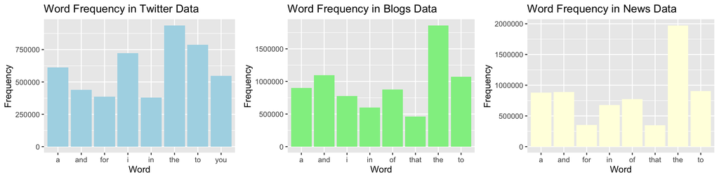

```r
par(mfrow=c(1,3))
twitter_words <- twitter %>% unnest_tokens(word, text) %>% count(word, sort=TRUE)
blog_words <- blogs %>% unnest_tokens(word, text) %>% count(word, sort=TRUE)
news_words <- news %>% unnest_tokens(word, text) %>% count(word, sort=TRUE)

twitter_plot <- ggplot(twitter_words[1:8,], aes(x=as.factor(word), y=n)) +
    geom_col(fill = "lightblue") + xlab('Word') + ylab('Frequency') +
    ggtitle('Word Frequency in Twitter Data')

blog_plot <- ggplot(blog_words[1:8,], aes(x=as.factor(word), y=n)) +
    geom_col(fill = "lightgreen") + xlab('Word') + ylab('Frequency') +
    ggtitle('Word Frequency in Blogs Data')

news_plot <- ggplot(news_words[1:8,], aes(x=as.factor(word), y=n)) +
    geom_col(fill = "lightyellow") + xlab('Word') + ylab('Frequency') +
    ggtitle('Word Frequency in News Data')

ggarrange(twitter_plot, blog_plot, news_plot, ncol=3)
```

```r
par(mfrow=c(1,3))
twitter_words_clean <- twitter %>% unnest_tokens(
  word,
  text,
  to_lower=TRUE,
  strip_punct=TRUE,
  strip_numeric=TRUE) %>%
  anti_join(stop_words) %>%
  count(word, sort=TRUE)
blog_words_clean <- blogs %>% unnest_tokens(
  word,
  text,
  to_lower=TRUE,
  strip_punct=TRUE,
  strip_numeric=TRUE) %>%
  anti_join(stop_words) %>%
  count(word, sort=TRUE)
news_words_clean <- news %>% unnest_tokens(
  word,
  text,
  to_lower=TRUE,
  strip_punct=TRUE,
  strip_numeric=TRUE) %>%
  anti_join(stop_words) %>%
  count(word, sort=TRUE)
```

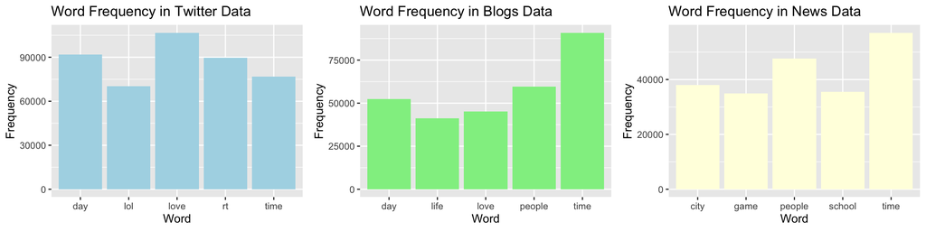

```r
twitter_plot <- ggplot(twitter_words_clean[1:5,], aes(x=as.factor(word), y=n)) +
  geom_col(fill = "lightblue") + xlab('Word') + ylab('Frequency') +
  ggtitle('Word Frequency in Twitter Data')

blog_plot <- ggplot(blog_words_clean[1:5,], aes(x=as.factor(word), y=n)) +
  geom_col(fill = "lightgreen") + xlab('Word') + ylab('Frequency') +
  ggtitle('Word Frequency in Blogs Data')

news_plot <- ggplot(news_words_clean[1:5,], aes(x=as.factor(word), y=n)) +
  geom_col(fill = "lightyellow") + xlab('Word') + ylab('Frequency') +
  ggtitle('Word Frequency in News Data')

ggarrange(twitter_plot, blog_plot, news_plot, ncol=3)
```

## Bigrams

Now let’s examine bigrams - pairs of words and how often they show up together. We combine the datasets from twitter, blogs, and news, and perform some cleaning up of the data - setting words to lowercase, removing punctuation, digits, and whitespace at the beginning and end of the sentences. We don’t remove the stop words in this case, because due to the data we have, when only looking at two word pairings, the pairings we get are including the stop words. So, for a sentence such as, `the house lies on the outskirts of the city.`, the pairing will be `the house`, instead of `house lies`. If we remove the stop words after we’ve created the bigrams we’re left with word pairings that don’t make much sense.

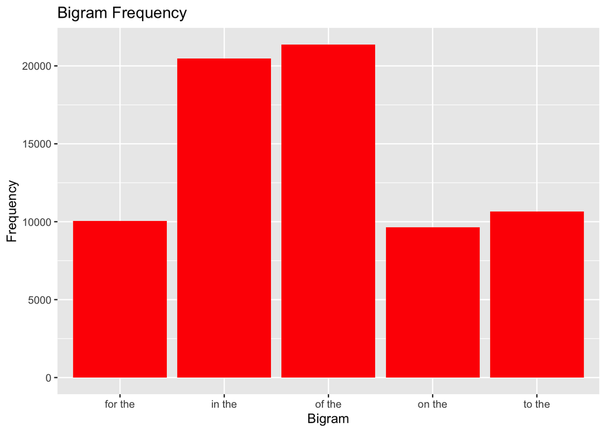

```r
twitter$source_type <- 'twitter'
blogs$source_type <- 'blogs'
news$source_type <- 'news'

en_combined_dataset <- rbind(
  sample_n(twitter, nrow(twitter)*0.05),
  sample_n(blogs, nrow(blogs)*0.05),
  sample_n(news, nrow(news)*0.05)
)

en_combined_dataset$text <- tolower(en_combined_dataset$text) # Set all words to be in lowercase
en_combined_dataset$text <- gsub("[[:punct:]]+", "", en_combined_dataset$text) # Remove punctuation from the text
en_combined_dataset$text <- gsub('[0-9]+', "", en_combined_dataset$text) # Remove numbers from the dataset
en_combined_dataset$text <- trimws(en_combined_dataset$text)

en_combined_dataset_bigram <- en_combined_dataset %>%
    unnest_tokens(bigram, text, token = "ngrams", n = 2) %>%
    count(bigram, sort = TRUE)

ggplot(en_combined_dataset_bigram[1:5,], aes(x=as.factor(bigram), y=n)) +
  geom_col(fill = "red") + xlab('Bigram') + ylab('Frequency') +
  ggtitle('Bigram Frequency')
```

## Trigram

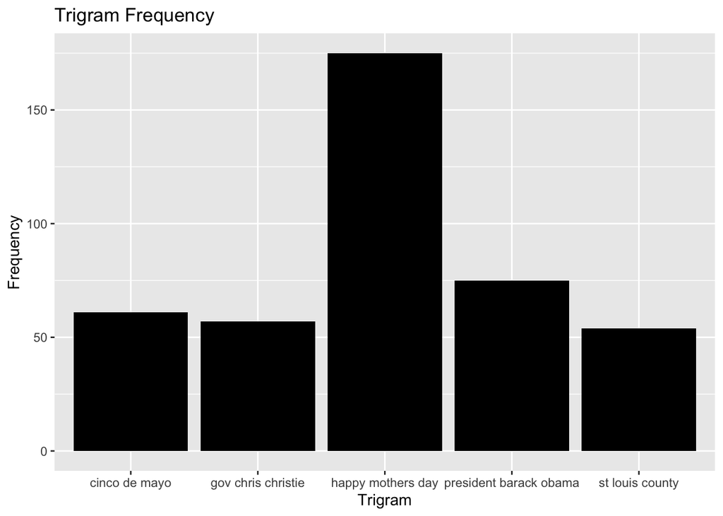

```r
en_combined_dataset_trigram <- en_combined_dataset %>%
    unnest_tokens(trigram, text, token = "ngrams", n = 3) %>%
    separate(trigram, c("word1", "word2", "word3"), sep = " ") %>%
    filter(!word1 %in% stop_words$word,
           !word2 %in% stop_words$word,
           !word3 %in% stop_words$word) %>%
    count(word1, word2, word3, sort = TRUE)

en_combined_dataset_trigram <- en_combined_dataset_trigram %>% unite(combined, word1, word2, word3, sep=" ")

ggplot(en_combined_dataset_trigram[2:6,], aes(x=as.factor(combined), y=n)) +
  geom_col(fill = "black") + xlab('Trigram') + ylab('Frequency') +
  ggtitle('Trigram Frequency')
```

## Next Steps

The next steps are creating a predictive model, which will predict the next word based on the current input from the user. The model will be based on the n-gram method, and will be deployed as a shiny app, along with a powerpoint presentation to explain how everything works.